# **Homework 3**

Kevin Ha

September 21, 2021

### **Problem 1**

##### Problem 1.1

The moment estimator can be determined by following the Law of Large Numbers which states that the sample moment will eventually converge to the corresponding population moment. Based on this, the first sample moment which is equivalent to the sample mean can be set equal to the first population moment, which is the expected value of the population and can be used to find the moment estimator.

For the first sample moment, $k = 1$

Sample mean: $\sum_{n}^{i = 1} X_i^1 = \overline{X}$

Population mean: $E(X_i) = \frac{0 + \theta}{2} = \theta / 2$

$\overline{X} = \theta / 2$

$\theta = 2\overline{X}$

$\hat{\theta}_M = 2\overline{X}$

##### Problem 1.2

The PDF of the given uniform distribution is the following:

$f(0, \theta) = \begin{cases} \frac{1}{\theta}, & 0 \leq x \leq \theta,\\ 0 & \text{otherwise }\end{cases}$

Next, the likelihood function, $L(\theta)$ will be calculated by the following:

$L(\theta) = \prod_{i=1}^{n} \frac{1}{\theta} = \theta^{-n}$

Then take the derivative of the logarithmic likelihood with respect to $\theta$ to find the maximizer for $L(\theta)$

$\frac{\mathrm{d} log L(\theta)}{d\theta} = -\frac{n}{\theta}$

Finally set it equal to 0 and solve the for $\hat{\theta}_L$

$-\frac{n}{\theta} = 0$

Since the function is decreasing and if we assume that the uniformly distributed random variables follow this order: $X_1 \leq X_2 \leq ... \leq X_n$, the largest value must be taken to to maximize the likelihood.

So, $\hat{\theta}_L = X_n$

##### Problem 1.3

Taking the mean and variance of the given SRS:

```r
x <- c(1.0, 2.4, 3.2, 1.3, 0.5, 3.2, 6.8)
mean(x)
```

```
## [1] 2.628571
```

```r
var(x)
```

```
## [1] 4.509048
```

$\hat{\theta}_M = 2\overline{X} = 2 (2.63) = 5.26$

$\hat{\theta}_K = X_n = 6.8$

In this case, $\hat{\theta}_M$ is better is it is closer to the observed variance parameter from the given SRS.

##### Problem 1.4

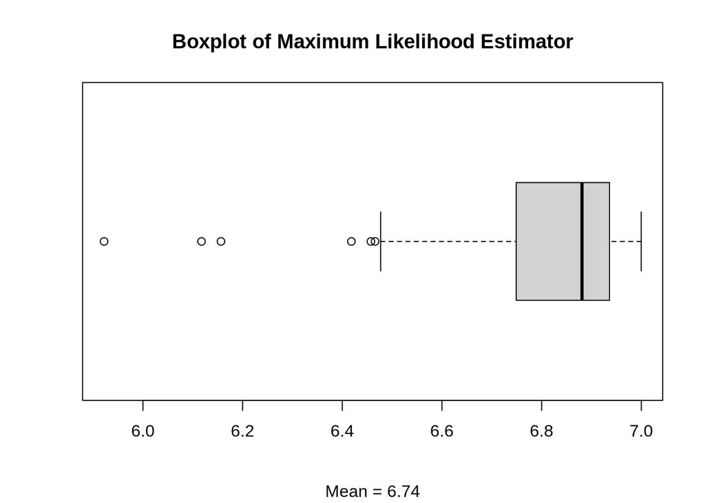

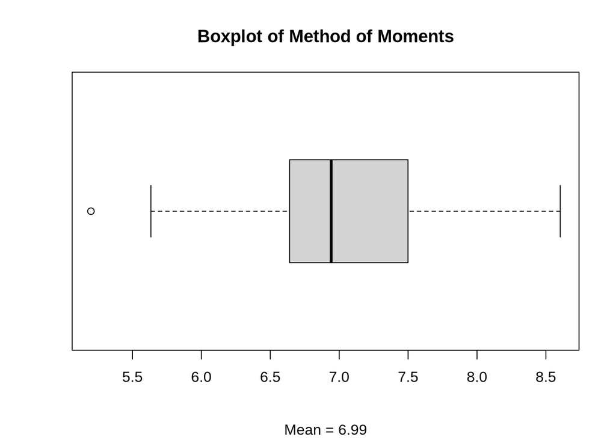

```r
sample_sim(30, 100, TRUE)
```

##### Problem 1.5

For $n = 20$

```
## [1] "Maximum likelihood estimator"
## [1] 6.282984
## [1] "Moment estimator"
## [1] 8.784863
```

For $n = 30$

```
## [1] "Maximum likelihood estimator"
## [1] 6.926516
## [1] "Moment estimator"
## [1] 7.192684
```

For $n = 50$

```
## [1] "Maximum likelihood estimator"
## [1] 6.967603
## [1] "Moment estimator"
## [1] 6.956946
```

For $n = 100$

```
## [1] "Maximum likelihood estimator"
## [1] 6.986621
## [1] "Moment estimator"
## [1] 8.230343
```

For $n = 150$

```
## [1] "Maximum likelihood estimator"
## [1] 6.998251
## [1] "Moment estimator"
## [1] 6.865233
```

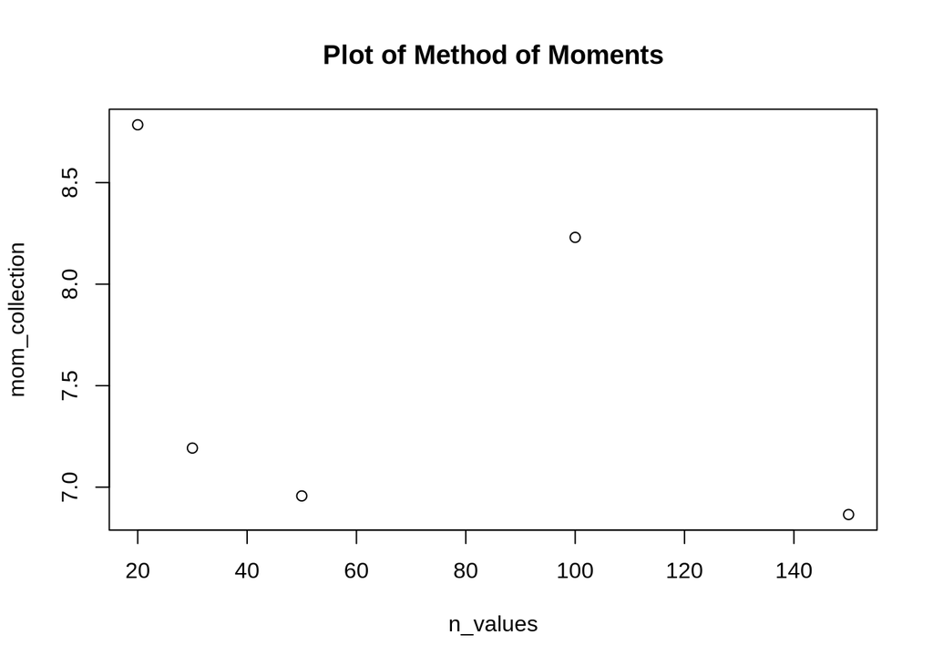

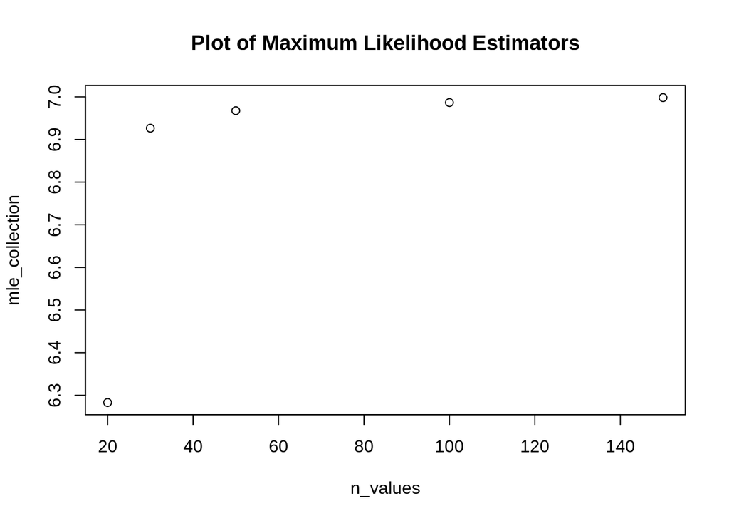

### **Problem 2**

##### Problem 2.1

First moment (mean): $\mu = E(X_i) = \frac{1}{n} \sum_{n=1}^{\infty} X_i$

Second moment (variance): $\sigma^2 = E(X^2_i) - \mu^2$

$\hat{\mu} = \frac{1}{n} \sum_{n=1}^{\infty} X_i = \bar{X}$

$\hat{\sigma} = \frac{1}{n} \sum_{n=1}^{\infty} X^2_i - \bar{X}^2 = \frac{1}{n} \sum_{n=1}^{\infty} (X_i - \bar{X})^2$

##### Problem 2.2

The Maximum Likelihood Estimator for the mean and variance is equivalent to the Method of Moments.

$\tilde{\mu} = \bar{X}$

$\tilde{\sigma}^2 = \frac{1}{n} \sum_{n=1}^{\infty} X^2_i - \bar{X}^2 = \frac{1}{n} \sum_{n=1}^{\infty} (X_i - \bar{X})^2$

##### Problem 2.3

Biasness for the mean can be tested if the following holds true: $E[\hat{\theta}(X_1, ... ,X_n)] = \theta$

$E(\bar{X}) = E(\frac{1}{n} \sum_{n=1}^{\infty} X_i) = \frac{1}{n} \sum_{n=1}^{\infty} E(X_i) = \frac{1}{n} \sum_{n=1}^{\infty} \mu = \frac{1}{n}(n\mu) = \mu$, **so $\hat{\mu}$ is unbiased**

Biasness for the variance can be tested similarly:

$E(\hat{\sigma}^2) = E(\frac{1}{n} \sum_{n=1}^{\infty} (X_i - \bar{X})^2) = \frac{(n-1)\sigma^2}{n}$

But since $E(\hat{\sigma}^2) = \frac{(n-1)\sigma^2}{n} \neq \sigma^2$, **which means that $\hat{\sigma}^2$ is biased**

##### Problem 2.4

Based on the the fact that both MLE and MoM are equivalent:

$\tilde{\mu}$ is **unbiased** and $\tilde{\sigma}^2$ is **biased**

### **Problem 3**

##### Problem 6.17 (a)

Margin of Error is calculated by: $Z * \frac{\sigma}{\sqrt{n}}$

Given a 95% confidence interval, $Z = 1.96$

MoE = $1.96 * \frac{2.3}{\sqrt{340}} = 0.24$

Confidence Interval: $(5.4 - 0.24, 5.4 + 0.24) = (5.16, 5.64)$

##### Problem 6.17 (b)

Margin of Error is calculated by: $Z * \frac{\sigma}{\sqrt{n}}$

Given a 99% confidence interval, $Z = 2.58$

MoE = $2.58 * \frac{2.3}{\sqrt{340}} = 0.32$

Confidence Interval: $(5.4 - 0.32, 5.4 + 0.32) = (5.08, 5.72)$

**The result is a larger range of values within the confidence interval compared to part a, this makes sense as the higher the confidence, the larger the margin of error.**

##### Problem 6.27 (a)

Margin of Error is calculated by: $Z * \frac{\sigma}{\sqrt{n}}$

Given a 95% confidence interval, $Z = 1.96$

MoE = $1.96 * \frac{8.3}{\sqrt{1200}} = 0.47$

Confidence Interval: $(11.5 - 0.47, 11.5 + 0.47) = (11.03, 11.97)$

##### Problem 6.27 (b)

**No, this is not true. The 95% confidence interval gives us 95% confidence that the population mean time spent listening to the radio per week lies between 11.03 and 11.97, and does not tell us anything about each sampled individual’s time.**

##### Problem 6.27 (c)

**The confidence interval is still a good approximation because the sample size affects the confidence interval, not the skewness of the distribution.**

##### Problem 6.28 (a)

Mean = $11.5 * 60 = 690$ minutes

Standard deviation = $8.3 * 60 = 498$ minutes

##### Problem 6.28 (b)

Margin of Error is calculated by: $Z * \frac{\sigma}{\sqrt{n}}$

Given a 95% confidence interval, $Z = 1.96$

MoE = $1.96 * \frac{498}{\sqrt{1200}} = 28.18$

Confidence Interval: $(690 - 28.18, 690 + 28.18) = (661.82, 718.18)$

##### Problem 6.28 (c)

**This interval could have been directly calculated by simply multiplying the Margin of Error by 60 to get the equivalent Margin of Error in minutes and then simply multiplying the mean by 60 as well to get the equivalent mean in minutes.**